# Predictive Analytics – Assignment 1

Apratim Dey Tapadar

2026-01-19

## Question 1

Report the “class” of the data set. How many rows and columns are in this data set? What do the rows and columns represent?

```r
library(MASS)
data(Boston)

class(Boston)
```

```
## [1] "data.frame"
```

```r
dim(Boston)
```

```
## [1] 506  14
```

The dataset contains 506 observations and 14 variables, indicating information collected across multiple Boston suburbs with several socio-economic and environmental attributes. Each row corresponds to a suburb of Boston, while each column represents a specific housing, environmental, or socio-economic variable. This suggests that the dataset is sufficiently large to capture variability across suburbs, making it suitable for exploratory and predictive analysis. From a predictive analytics perspective, the presence of multiple explanatory variables allows us to examine how different factors jointly influence housing prices.

## Question 2

Create a smaller data set with the variables median value of owner-occupied homes, per capita crime rate, nitrogen oxides concentration, proportion of blacks and percentage of lower status of the population. Choosing median value of owner occupied homes as the response and the rest as the pre- dictors, make scatter plots of the response versus each predictor. Present the scatter plots in different panels of the same graph. Comment on your findings.

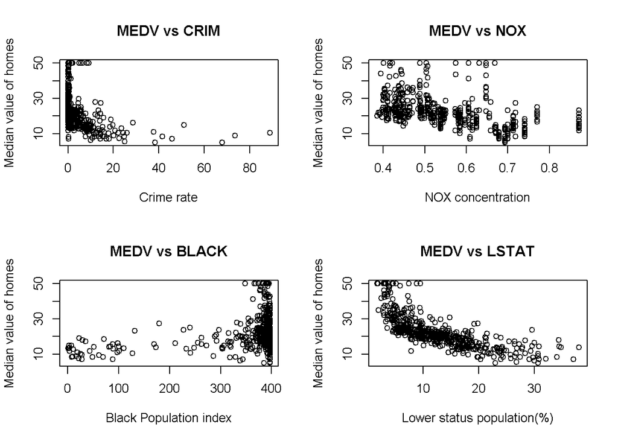

```r
small_boston = Boston[,c("medv","crim","nox","black","lstat")]
par(mfrow=c(2,2))

plot(small_boston$crim,small_boston$medv,
     xlab="Crime rate",
     ylab="Median value of homes",
     main="MEDV vs CRIM")

plot(small_boston$nox,small_boston$medv,
     xlab="NOX concentration",
     ylab="Median value of homes",
     main="MEDV vs NOX")

plot(small_boston$black,small_boston$medv,
     xlab="Black Population index",
     ylab="Median value of homes",
     main="MEDV vs BLACK")

plot(small_boston$lstat,small_boston$medv,
     xlab="Lower status population(%)",
     ylab="Median value of homes",
     main="MEDV vs LSTAT")
```

MEDV vs CRIM: Clear negative relationship → higher crime rate corresponds to lower house values.

MEDV vs NOX: Strong negative association → polluted areas tend to have cheaper housing.

MEDV vs BLACK: Weak and nonlinear relationship → not a strong direct predictor.

MEDV vs LSTAT: Very strong negative relationship → suburbs with higher lower-status population have much lower house prices.

Conclusion: The scatter plots indicate strong negative associations between median house value and lstat, crim, and nox. Among these, lstat exhibits the strongest and most consistent relationship, followed by crim and nox, while black shows a comparatively weaker association.

## Question 3

Which suburb of Boston has lowest median value of owner-occupied homes? What are the values of the other predictors mentioned in (2), for that suburb. How do these values compare to the overall ranges for those predictors? Comment on your findings. Hint: Mention which percentile these values belong to.

```r
min_index = which.min(Boston$medv)


Boston[min_index, c("medv", "crim", "nox", "black", "lstat")]
```

```
##     medv    crim   nox black lstat
## 399    5 38.3518 0.693 396.9 30.59
```

```r
sapply(
  c("crim", "nox", "black", "lstat"),
  function(var) {
    ecdf(Boston[[var]])(Boston[min_index, var])
  }
)
```

```
##      crim       nox     black     lstat
## 0.9881423 0.8577075 1.0000000 0.9782609
```

Crime → 98th percentile (extremely high)

LSTAT → 97th percentile (very high lower-status population)

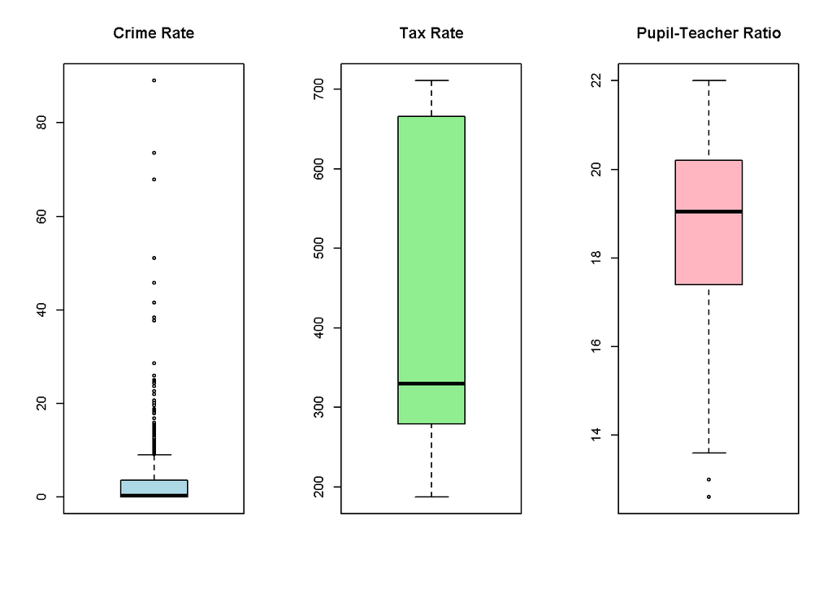

```r
par(mfrow = c(1, 3))

boxplot(Boston$crim, main = "Crime Rate", col = "lightblue")
boxplot(Boston$tax, main = "Tax Rate", col = "lightgreen")
boxplot(Boston$ptratio, main = "Pupil-Teacher Ratio", col = "lightpink")
```

```r
which(Boston$crim %in% boxplot.stats(Boston$crim)$out)
```

```
##  [1] 368 372 374 375 376 377 378 379 380 381 382 383 385 386 387 388 389 393 395
## [20] 399 400 401 402 403 404 405 406 407 408 410 411 412 413 414 415 416 417 418
## [39] 419 420 421 423 426 427 428 430 432 435 436 437 438 439 440 441 442 444 445
## [58] 446 448 449 455 469 470 478 479 480
```

```r
which(Boston$tax %in% boxplot.stats(Boston$tax)$out)
```

```
## integer(0)
```

```r
which(Boston$ptratio %in% boxplot.stats(Boston$ptratio)$out)
```

```
##  [1] 197 198 199 258 259 260 261 262 263 264 265 266 267 268 269
```